# Short software tutorial on `nonprobsvy` package – replicating results from the Yang et al. (2020)

### 1.3.2 Estimators under PSM I

Naive estimator.

```r
est_naive <- aggregate(cbind(Y_11,Y_12,Y_21,Y_22) ~ 1, sample_B1, mean)
est_naive
```

IPW with variable selection using SCAD penalty (note that this IPW is IPW with calibration constraints on selected variables).

```r
est_ipw_y11 <- nonprob(selection = X_formula,
                       target = ~ Y_11,
                       data = sample_B1,
                       svydesign = sample_A_svy_Y11,
                       control_inference = controlInf(vars_selection = TRUE))

est_ipw_y12 <- nonprob(selection = X_formula,
                       target = ~ Y_12,
                       data = sample_B1,
                       svydesign = sample_A_svy_Y12,
                       control_inference = controlInf(vars_selection = TRUE))

est_ipw_y21 <- nonprob(selection = X_formula,
                       target = ~ Y_21,
                       data = sample_B1,
                       svydesign = sample_A_svy_Y21,
                       control_inference = controlInf(vars_selection = TRUE))

est_ipw_y22 <- nonprob(selection = X_formula,
                       target = ~ Y_22,
                       data = sample_B1,
                       svydesign = sample_A_svy_Y22,
                       control_inference = controlInf(vars_selection = TRUE))
```

Mass imputation with SCAD penalty.

```r
est_mi_y11 <- nonprob(outcome = as.formula(paste("Y_11 ~ ", as.character(X_formula)[2])),
                      data = sample_B1,
                      svydesign = sample_A_svy_Y11,
                      control_inference = controlInf(vars_selection = TRUE),
                      family_outcome = "gaussian")
est_mi_y12 <- nonprob(outcome = as.formula(paste("Y_12 ~ ", as.character(X_formula)[2])),
                      data = sample_B1,
                      svydesign = sample_A_svy_Y12,
                      control_inference = controlInf(vars_selection = TRUE),
                      family_outcome = "gaussian")
est_mi_y21 <- nonprob(outcome = as.formula(paste("Y_21 ~ ", as.character(X_formula)[2])),
                      data = sample_B1,
                      svydesign = sample_A_svy_Y21,
                      control_inference = controlInf(vars_selection = TRUE),
                      family_outcome = "binomial")
est_mi_y22 <- nonprob(outcome = as.formula(paste("Y_22 ~ ", as.character(X_formula)[2])),
                      data = sample_B1,
                      svydesign = sample_A_svy_Y22,
                      control_inference = controlInf(vars_selection = TRUE),
                      family_outcome = "binomial")
```

DR with variables based on mass imputation with SCAD penalty.

```r
est_dr_pred_y11 <- nonprob(outcome = as.formula(paste("Y_11 ~ ",
                                                      paste(names(est_mi_y11$outcome$Y_11$coefficients)[-1],
                                                            collapse = "+"))),
                           selection = as.formula(paste(" ~ ",
                                                      paste(names(est_mi_y11$outcome$Y_11$coefficients)[-1],
                                                            collapse = "+"))),
                           data = sample_B1,
                           svydesign = sample_A_svy_Y11,
                           family_outcome = "gaussian")
est_dr_pred_y12 <- nonprob(outcome = as.formula(paste("Y_12 ~ ",
                                                      paste(names(est_mi_y12$outcome$Y_12$coefficients)[-1],
                                                            collapse = "+"))),
                           selection = as.formula(paste(" ~ ",
                                                      paste(names(est_mi_y12$outcome$Y_12$coefficients)[-1],
                                                            collapse = "+"))),
                           data = sample_B1,
                           svydesign = sample_A_svy_Y12,
                           family_outcome = "gaussian")
est_dr_pred_y21 <- nonprob(outcome = as.formula(paste("Y_21 ~ ",
                                                      paste(names(est_mi_y21$outcome$Y_21$coefficients)[-1],
                                                            collapse = "+"))),
                           selection = as.formula(paste(" ~ ",
                                                      paste(names(est_mi_y21$outcome$Y_21$coefficients)[-1],
                                                            collapse = "+"))),
                           data = sample_B1,
                           svydesign = sample_A_svy_Y21,
                           family_outcome = "binomial")
est_dr_pred_y22 <- nonprob(outcome = as.formula(paste("Y_22 ~ ",
                                                      paste(names(est_mi_y22$outcome$Y_22$coefficients)[-1],
                                                            collapse = "+"))),
                           selection = as.formula(paste(" ~ ",
                                                      paste(names(est_mi_y22$outcome$Y_22$coefficients)[-1],
                                                            collapse = "+"))),
                           data = sample_B1,
                           svydesign = sample_A_svy_Y22,
                           family_outcome = "binomial")
```

DR without bias minimization but with union of variables.

```r
est_dr_y11 <- nonprob(outcome = as.formula(paste("Y_11 ~ ", as.character(X_formula)[2])),
                     selection = X_formula,
                     data = sample_B1,
                     svydesign = sample_A_svy_Y11,
                     control_inference = controlInf(vars_selection = TRUE),
                     family_outcome = "gaussian")
est_dr_y12 <- nonprob(outcome = as.formula(paste("Y_12 ~ ", as.character(X_formula)[2])),
                     selection = X_formula,
                     data = sample_B1,
                     svydesign = sample_A_svy_Y12,
                     control_inference = controlInf(vars_selection = TRUE),
                     family_outcome = "gaussian")
est_dr_y21 <- nonprob(outcome = as.formula(paste("Y_21 ~ ", as.character(X_formula)[2])),
                     selection = X_formula,
                     data = sample_B1,
                     svydesign = sample_A_svy_Y21,
                     control_inference = controlInf(vars_selection = TRUE),
                     family_outcome = "binomial")
est_dr_y22 <- nonprob(outcome = as.formula(paste("Y_22 ~ ", as.character(X_formula)[2])),
                     selection = X_formula,
                     data = sample_B1,
                     svydesign = sample_A_svy_Y22,
                     control_inference = controlInf(vars_selection = TRUE),
                     family_outcome = "binomial")
```

DR with bias minimization with union of variables after selection of variables with SCAD.

```r
est_dr_mm_y11 <- nonprob(outcome = as.formula(paste("Y_11 ~ ", paste(names(est_dr_y11$outcome$Y_11$coefficients)[-1], collapse = "+"))),
                         selection = as.formula(paste(" ~ ", paste(names(est_dr_y11$selection$coefficients)[-1], collapse = "+"))),
                         data = sample_B1,
                         svydesign = sample_A_svy_Y11,
                         control_inference = controlInf(bias_correction = TRUE),
                         family_outcome = "gaussian")
est_dr_mm_y12 <- nonprob(outcome = as.formula(paste("Y_12 ~ ", paste(names(est_dr_y12$outcome$Y_12$coefficients)[-1], collapse = "+"))),
                         selection = as.formula(paste(" ~ ", paste(names(est_dr_y12$selection$coefficients)[-1], collapse = "+"))),
                         data = sample_B1,
                         svydesign = sample_A_svy_Y12,
                         control_inference = controlInf(bias_correction = TRUE),
                         family_outcome = "gaussian")
est_dr_mm_y21 <- nonprob(outcome = as.formula(paste("Y_21 ~ ", paste(names(est_dr_y21$outcome$Y_21$coefficients)[-1], collapse = "+"))),
                         selection = as.formula(paste(" ~ ", paste(names(est_dr_y21$selection$coefficients)[-1], collapse = "+"))),
                         data = sample_B1,
                         svydesign = sample_A_svy_Y21,
                         control_inference = controlInf(bias_correction = TRUE),
                         family_outcome = "binomial")
est_dr_mm_y22 <- nonprob(outcome = as.formula(paste("Y_22 ~ ", paste(names(est_dr_y22$outcome$Y_22$coefficients)[-1], collapse = "+"))),
                         selection = as.formula(paste(" ~ ", paste(names(est_dr_y22$selection$coefficients)[-1], collapse = "+"))),
                         data = sample_B1,
                         svydesign = sample_A_svy_Y22,
                         control_inference = controlInf(bias_correction = TRUE),
                         family_outcome = "binomial")
```

Compare results

```r
results <- rbind(
  cbind(est_ipw_y11$output,est_ipw_y11$confidence_interval),
  cbind(est_ipw_y12$output,est_ipw_y12$confidence_interval),
  cbind(est_ipw_y21$output,est_ipw_y21$confidence_interval),
  cbind(est_ipw_y22$output,est_ipw_y22$confidence_interval),
  cbind(est_mi_y11$output,est_mi_y11$confidence_interval),
  cbind(est_mi_y12$output,est_mi_y12$confidence_interval),
  cbind(est_mi_y21$output,est_mi_y21$confidence_interval),
  cbind(est_mi_y22$output,est_mi_y22$confidence_interval),
  cbind(est_dr_pred_y11$output,est_dr_pred_y11$confidence_interval),
  cbind(est_dr_pred_y12$output,est_dr_pred_y12$confidence_interval),
  cbind(est_dr_pred_y21$output,est_dr_pred_y21$confidence_interval),
  cbind(est_dr_pred_y22$output,est_dr_pred_y22$confidence_interval),
  cbind(est_dr_y11$output,est_dr_y11$confidence_interval),
  cbind(est_dr_y12$output,est_dr_y12$confidence_interval),
  cbind(est_dr_y21$output,est_dr_y21$confidence_interval),
  cbind(est_dr_y22$output,est_dr_y22$confidence_interval),
  cbind(est_dr_mm_y11$output,est_dr_mm_y11$confidence_interval),
  cbind(est_dr_mm_y12$output,est_dr_mm_y12$confidence_interval),
  cbind(est_dr_mm_y21$output,est_dr_mm_y21$confidence_interval),
  cbind(est_dr_mm_y22$output,est_dr_mm_y22$confidence_interval),
  data.frame(mean = t(est_naive), SE = NA, lower_bound = NA, upper_bound = NA)
)
rownames(results) <- NULL
results$y <- rep(c("Y_11", "Y_12", "Y_21", "Y_22"), rep = 6)
results$estim <- rep(c("IPW", "MI", "DR (MI vars)", "DR (SCAD)", "DR (SCAD and BM)", "Naive"), each = 4)
results$estim <- factor(results$estim, c("Naive", "IPW", "MI", "DR (MI vars)", "DR (SCAD)", "DR (SCAD and BM)"))
results$true  <- rep(c(mean(Y_11), mean(Y_12), mean(Y_21), mean(Y_22)), rep = 6)
results <- results[, c("y", "estim", "mean", "SE", "lower_bound", "upper_bound", "true")]
results <- results[order(results$y, results$estim),]
```

|  | y | estim | mean | SE | lower_bound | upper_bound | true |
| --- | --- | --- | --- | --- | --- | --- | --- |
| 21 | Y_11 | Naive | 1.9436859 | NA | NA | NA | 0.9823814 |
| 1 | Y_11 | IPW | 0.9116848 | 0.3247924 | 0.2751034 | 1.5482661 | 0.9823814 |
| 5 | Y_11 | MI | 0.9828881 | 0.1121626 | 0.7630535 | 1.2027227 | 0.9823814 |
| 9 | Y_11 | DR (MI vars) | 0.9879241 | 0.1166265 | 0.7593404 | 1.2165078 | 0.9823814 |
| 13 | Y_11 | DR (SCAD) | 1.0630343 | 0.1217627 | 0.8243838 | 1.3016847 | 0.9823814 |
| 17 | Y_11 | DR (SCAD and BM) | 1.0524182 | 0.1149401 | 0.8271397 | 1.2776966 | 0.9823814 |
| 22 | Y_12 | Naive | 7.0130489 | NA | NA | NA | 6.8326961 |
| 2 | Y_12 | IPW | 6.6809742 | 0.3182248 | 6.0572651 | 7.3046833 | 6.8326961 |
| 6 | Y_12 | MI | 7.4668711 | 0.2310717 | 7.0139789 | 7.9197633 | 6.8326961 |
| 10 | Y_12 | DR (MI vars) | 6.3150196 | 0.5306529 | 5.2749589 | 7.3550802 | 6.8326961 |
| 14 | Y_12 | DR (SCAD) | 5.9393856 | 1.1088517 | 3.7660762 | 8.1126951 | 6.8326961 |
| 18 | Y_12 | DR (SCAD and BM) | 6.2746572 | 0.2847375 | 5.7165819 | 6.8327325 | 6.8326961 |
| 23 | Y_21 | Naive | 0.7739634 | NA | NA | NA | 0.6464000 |
| 3 | Y_21 | IPW | 0.5655469 | 0.0762642 | 0.4160719 | 0.7150219 | 0.6464000 |
| 7 | Y_21 | MI | 0.6260188 | 0.0194514 | 0.5878948 | 0.6641427 | 0.6464000 |
| 11 | Y_21 | DR (MI vars) | 0.6338268 | 0.0215508 | 0.5915880 | 0.6760656 | 0.6464000 |
| 15 | Y_21 | DR (SCAD) | 0.5967640 | 0.0291263 | 0.5396775 | 0.6538505 | 0.6464000 |
| 19 | Y_21 | DR (SCAD and BM) | 0.5874211 | 0.0235020 | 0.5413580 | 0.6334842 | 0.6464000 |
| 24 | Y_22 | Naive | 0.5969683 | NA | NA | NA | 0.6492000 |
| 4 | Y_22 | IPW | 0.6582915 | 0.0238749 | 0.6114975 | 0.7050855 | 0.6492000 |
| 8 | Y_22 | MI | 0.6737714 | 0.0188189 | 0.6368870 | 0.7106559 | 0.6492000 |
| 12 | Y_22 | DR (MI vars) | 0.6642269 | 0.0187117 | 0.6275527 | 0.7009012 | 0.6492000 |
| 16 | Y_22 | DR (SCAD) | 0.6877744 | 0.0274512 | 0.6339711 | 0.7415777 | 0.6492000 |
| 20 | Y_22 | DR (SCAD and BM) | 0.6784483 | 0.0220169 | 0.6352959 | 0.7216006 | 0.6492000 |

Plot results from one go

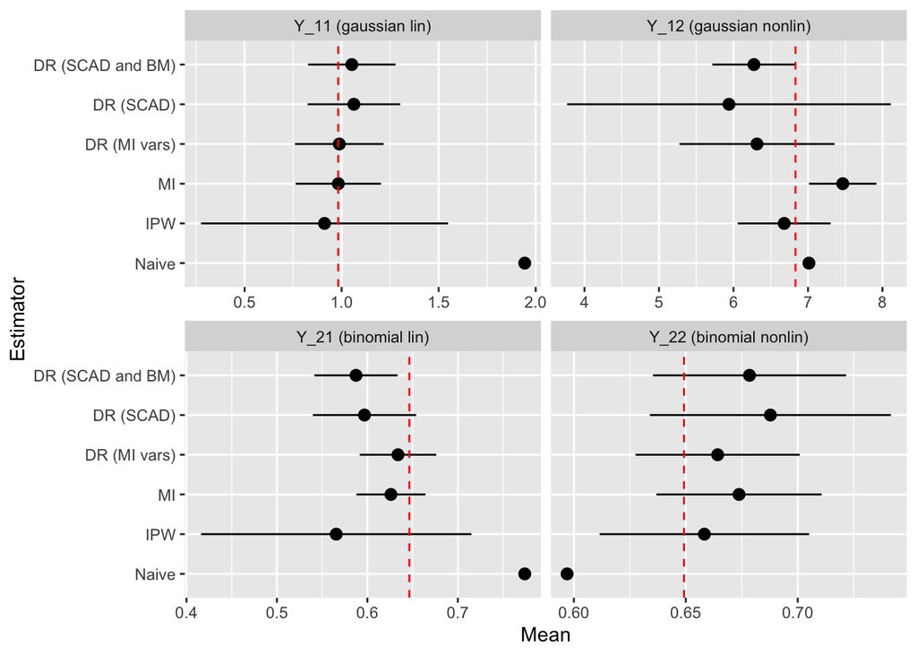

```r
ggplot(data = results, aes(x = estim, y = mean, ymin = lower_bound, ymax = upper_bound)) +
  geom_point() +
  geom_pointrange() +
  geom_hline(aes(yintercept = true), color = "red", linetype = "dashed") +
  facet_wrap(~y, scales = "free_x", labeller = labeller(y = c("Y_11" = "Y_11 (gaussian lin)",
                                                              "Y_12" = "Y_12 (gaussian nonlin)",
                                                              "Y_21" = "Y_21 (binomial lin)",
                                                              "Y_22" = "Y_22 (binomial nonlin)"))) +
  coord_flip() +
  labs(y = "Mean", x = "Estimator")
```

### 1.3.3 Estimators under PSM II

Naive estimator.

```r
est_naive <- aggregate(cbind(Y_11,Y_12,Y_21,Y_22) ~ 1, sample_B2, mean)
```

IPW with variable selection using SCAD penalty (note that this IPW is IPW with calibration constraints on selected variables).

```r
est_ipw_y11 <- nonprob(selection = X_formula,
                       target = ~ Y_11,
                       data = sample_B2,
                       svydesign = sample_A_svy_Y11,
                       control_inference = controlInf(vars_selection = TRUE))

est_ipw_y12 <- nonprob(selection = X_formula,
                       target = ~ Y_12,
                       data = sample_B2,
                       svydesign = sample_A_svy_Y12,
                       control_inference = controlInf(vars_selection = TRUE))

est_ipw_y21 <- nonprob(selection = X_formula,
                       target = ~ Y_21,
                       data = sample_B2,
                       svydesign = sample_A_svy_Y21,
                       control_inference = controlInf(vars_selection = TRUE))

est_ipw_y22 <- nonprob(selection = X_formula,
                       target = ~ Y_22,
                       data = sample_B2,
                       svydesign = sample_A_svy_Y22,
                       control_inference = controlInf(vars_selection = TRUE))
```

Mass imputation with SCAD penalty.

```r
est_mi_y11 <- nonprob(outcome = as.formula(paste("Y_11 ~ ", as.character(X_formula)[2])),
                      data = sample_B2,
                      svydesign = sample_A_svy_Y11,
                      control_inference = controlInf(vars_selection = TRUE),
                      family_outcome = "gaussian")
est_mi_y12 <- nonprob(outcome = as.formula(paste("Y_12 ~ ", as.character(X_formula)[2])),
                      data = sample_B2,
                      svydesign = sample_A_svy_Y12,
                      control_inference = controlInf(vars_selection = TRUE),
                      family_outcome = "gaussian")
est_mi_y21 <- nonprob(outcome = as.formula(paste("Y_21 ~ ", as.character(X_formula)[2])),
                      data = sample_B2,
                      svydesign = sample_A_svy_Y21,
                      control_inference = controlInf(vars_selection = TRUE),
                      family_outcome = "binomial")
est_mi_y22 <- nonprob(outcome = as.formula(paste("Y_22 ~ ", as.character(X_formula)[2])),
                      data = sample_B2,
                      svydesign = sample_A_svy_Y22,
                      control_inference = controlInf(vars_selection = TRUE),
                      family_outcome = "binomial")
```

DR with variables based on mass imputation with SCAD penalty.

```r
est_dr_pred_y11 <- nonprob(outcome = as.formula(paste("Y_11 ~ ",
                                                      paste(names(est_mi_y11$outcome$Y_11$coefficients)[-1],
                                                            collapse = "+"))),
                           selection = as.formula(paste(" ~ ",
                                                      paste(names(est_mi_y11$outcome$Y_11$coefficients)[-1],
                                                            collapse = "+"))),
                           data = sample_B2,
                           svydesign = sample_A_svy_Y11,
                           family_outcome = "gaussian")
est_dr_pred_y12 <- nonprob(outcome = as.formula(paste("Y_12 ~ ",
                                                      paste(names(est_mi_y12$outcome$Y_12$coefficients)[-1],
                                                            collapse = "+"))),
                           selection = as.formula(paste(" ~ ",
                                                      paste(names(est_mi_y12$outcome$Y_12$coefficients)[-1],
                                                            collapse = "+"))),
                           data = sample_B2,
                           svydesign = sample_A_svy_Y12,
                           family_outcome = "gaussian")
est_dr_pred_y21 <- nonprob(outcome = as.formula(paste("Y_21 ~ ",
                                                      paste(names(est_mi_y21$outcome$Y_21$coefficients)[-1],
                                                            collapse = "+"))),
                           selection = as.formula(paste(" ~ ",
                                                      paste(names(est_mi_y21$outcome$Y_21$coefficients)[-1],
                                                            collapse = "+"))),
                           data = sample_B2,
                           svydesign = sample_A_svy_Y21,
                           family_outcome = "binomial")
est_dr_pred_y22 <- nonprob(outcome = as.formula(paste("Y_22 ~ ",
                                                      paste(names(est_mi_y22$outcome$Y_22$coefficients)[-1],
                                                            collapse = "+"))),
                           selection = as.formula(paste(" ~ ",
                                                      paste(names(est_mi_y22$outcome$Y_22$coefficients)[-1],
                                                            collapse = "+"))),
                           data = sample_B2,
                           svydesign = sample_A_svy_Y22,
                           family_outcome = "binomial")
```

DR without bias minimization but with union of variables.

```r
est_dr_y11 <- nonprob(outcome = as.formula(paste("Y_11 ~ ", as.character(X_formula)[2])),
                     selection = X_formula,
                     data = sample_B2,
                     svydesign = sample_A_svy_Y11,
                     control_inference = controlInf(vars_selection = TRUE),
                     family_outcome = "gaussian")
est_dr_y12 <- nonprob(outcome = as.formula(paste("Y_12 ~ ", as.character(X_formula)[2])),
                     selection = X_formula,
                     data = sample_B2,
                     svydesign = sample_A_svy_Y12,
                     control_inference = controlInf(vars_selection = TRUE),
                     family_outcome = "gaussian")
est_dr_y21 <- nonprob(outcome = as.formula(paste("Y_21 ~ ", as.character(X_formula)[2])),
                     selection = X_formula,
                     data = sample_B2,
                     svydesign = sample_A_svy_Y21,
                     control_inference = controlInf(vars_selection = TRUE),
                     family_outcome = "binomial")
est_dr_y22 <- nonprob(outcome = as.formula(paste("Y_22 ~ ", as.character(X_formula)[2])),
                     selection = X_formula,
                     data = sample_B2,
                     svydesign = sample_A_svy_Y22,
                     control_inference = controlInf(vars_selection = TRUE),
                     family_outcome = "binomial")
```

DR with bias minimization with union of variables after selection of variables with SCAD.

```r
est_dr_mm_y11 <- nonprob(outcome = as.formula(paste("Y_11 ~ ", paste(names(est_dr_y11$outcome$Y_11$coefficients)[-1], collapse = "+"))),
                         selection = as.formula(paste(" ~ ", paste(names(est_dr_y11$selection$coefficients)[-1], collapse = "+"))),
                         data = sample_B2,
                         svydesign = sample_A_svy_Y11,
                         control_inference = controlInf(bias_correction = TRUE),
                         family_outcome = "gaussian")
est_dr_mm_y12 <- nonprob(outcome = as.formula(paste("Y_12 ~ ", paste(names(est_dr_y12$outcome$Y_12$coefficients)[-1], collapse = "+"))),
                         selection = as.formula(paste(" ~ ", paste(names(est_dr_y12$selection$coefficients)[-1], collapse = "+"))),
                         data = sample_B2,
                         svydesign = sample_A_svy_Y12,
                         control_inference = controlInf(bias_correction = TRUE),
                         family_outcome = "gaussian")
est_dr_mm_y21 <- nonprob(outcome = as.formula(paste("Y_21 ~ ", paste(names(est_dr_y21$outcome$Y_21$coefficients)[-1], collapse = "+"))),
                         selection = as.formula(paste(" ~ ", paste(names(est_dr_y21$selection$coefficients)[-1], collapse = "+"))),
                         data = sample_B2,
                         svydesign = sample_A_svy_Y21,
                         control_inference = controlInf(bias_correction = TRUE),
                         family_outcome = "binomial")
est_dr_mm_y22 <- nonprob(outcome = as.formula(paste("Y_22 ~ ", paste(names(est_dr_y22$outcome$Y_22$coefficients)[-1], collapse = "+"))),
                         selection = as.formula(paste(" ~ ", paste(names(est_dr_y22$selection$coefficients)[-1], collapse = "+"))),
                         data = sample_B2,
                         svydesign = sample_A_svy_Y22,
                         control_inference = controlInf(bias_correction = TRUE),
                         family_outcome = "binomial")
```

Compare results

```r
results <- rbind(
  cbind(est_ipw_y11$output,est_ipw_y11$confidence_interval),
  cbind(est_ipw_y12$output,est_ipw_y12$confidence_interval),
  cbind(est_ipw_y21$output,est_ipw_y21$confidence_interval),
  cbind(est_ipw_y22$output,est_ipw_y22$confidence_interval),
  cbind(est_mi_y11$output,est_mi_y11$confidence_interval),
  cbind(est_mi_y12$output,est_mi_y12$confidence_interval),
  cbind(est_mi_y21$output,est_mi_y21$confidence_interval),
  cbind(est_mi_y22$output,est_mi_y22$confidence_interval),
  cbind(est_dr_pred_y11$output,est_dr_pred_y11$confidence_interval),
  cbind(est_dr_pred_y12$output,est_dr_pred_y12$confidence_interval),
  cbind(est_dr_pred_y21$output,est_dr_pred_y21$confidence_interval),
  cbind(est_dr_pred_y22$output,est_dr_pred_y22$confidence_interval),
  cbind(est_dr_y11$output,est_dr_y11$confidence_interval),
  cbind(est_dr_y12$output,est_dr_y12$confidence_interval),
  cbind(est_dr_y21$output,est_dr_y21$confidence_interval),
  cbind(est_dr_y22$output,est_dr_y22$confidence_interval),
  cbind(est_dr_mm_y11$output,est_dr_mm_y11$confidence_interval),
  cbind(est_dr_mm_y12$output,est_dr_mm_y12$confidence_interval),
  cbind(est_dr_mm_y21$output,est_dr_mm_y21$confidence_interval),
  cbind(est_dr_mm_y22$output,est_dr_mm_y22$confidence_interval),
  data.frame(mean = t(est_naive), SE = NA, lower_bound = NA, upper_bound = NA)
)
rownames(results) <- NULL
results$y <- rep(c("Y_11", "Y_12", "Y_21", "Y_22"), rep = 4)
results$estim <- rep(c("IPW", "MI", "DR (MI vars)",
                       "DR (SCAD)",
                       "DR (SCAD and BM)",
                       "Naive"), each = 4)
results$estim <- factor(results$estim, c("Naive", "IPW", "MI", "DR (MI vars)"
                                         ,"DR (SCAD)",
                                         "DR (SCAD and BM)"
                                         ))
results$true  <- rep(c(mean(Y_11), mean(Y_12), mean(Y_21), mean(Y_22)), rep = 6)
results <- results[, c("y", "estim", "mean", "SE", "lower_bound", "upper_bound", "true")]
results <- results[order(results$y, results$estim),]
```

|  | y | estim | mean | SE | lower_bound | upper_bound | true |
| --- | --- | --- | --- | --- | --- | --- | --- |
| 21 | Y_11 | Naive | 0.8690708 | NA | NA | NA | 0.9823814 |
| 1 | Y_11 | IPW | 1.1408194 | 0.2763044 | 0.5992727 | 1.6823661 | 0.9823814 |
| 5 | Y_11 | MI | 0.9852815 | 0.1099387 | 0.7698056 | 1.2007575 | 0.9823814 |
| 9 | Y_11 | DR (MI vars) | 0.9864055 | 0.1109693 | 0.7689098 | 1.2039013 | 0.9823814 |
| 13 | Y_11 | DR (SCAD) | 0.9927627 | 0.1128372 | 0.7716058 | 1.2139195 | 0.9823814 |
| 17 | Y_11 | DR (SCAD and BM) | 0.9953213 | 0.1103321 | 0.7790743 | 1.2115682 | 0.9823814 |
| 22 | Y_12 | Naive | 5.6923031 | NA | NA | NA | 6.8326961 |
| 2 | Y_12 | IPW | 5.3265479 | 0.2935010 | 4.7512965 | 5.9017993 | 6.8326961 |
| 6 | Y_12 | MI | 5.5226722 | 0.1734962 | 5.1826258 | 5.8627185 | 6.8326961 |
| 10 | Y_12 | DR (MI vars) | 5.5488061 | 0.1650126 | 5.2253873 | 5.8722249 | 6.8326961 |
| 14 | Y_12 | DR (SCAD) | 5.5459985 | 0.1790489 | 5.1950692 | 5.8969279 | 6.8326961 |
| 18 | Y_12 | DR (SCAD and BM) | 5.5475235 | 0.1587413 | 5.2363963 | 5.8586507 | 6.8326961 |
| 23 | Y_21 | Naive | 0.6121693 | NA | NA | NA | 0.6464000 |
| 3 | Y_21 | IPW | 0.5726812 | 0.0298844 | 0.5141088 | 0.6312536 | 0.6464000 |
| 7 | Y_21 | MI | 0.6440307 | 0.0183756 | 0.6080153 | 0.6800461 | 0.6464000 |
| 11 | Y_21 | DR (MI vars) | 0.6449616 | 0.0173765 | 0.6109043 | 0.6790188 | 0.6464000 |
| 15 | Y_21 | DR (SCAD) | 0.6443191 | 0.0180487 | 0.6089442 | 0.6796939 | 0.6464000 |
| 19 | Y_21 | DR (SCAD and BM) | 0.6470456 | 0.0174661 | 0.6128127 | 0.6812785 | 0.6464000 |
| 24 | Y_22 | Naive | 0.6402116 | NA | NA | NA | 0.6492000 |
| 4 | Y_22 | IPW | 0.5688062 | 0.0303166 | 0.5093867 | 0.6282257 | 0.6492000 |
| 8 | Y_22 | MI | 0.5985632 | 0.0186398 | 0.5620299 | 0.6350964 | 0.6492000 |
| 12 | Y_22 | DR (MI vars) | 0.5976334 | 0.0171870 | 0.5639475 | 0.6313193 | 0.6492000 |
| 16 | Y_22 | DR (SCAD) | 0.6061048 | 0.0176603 | 0.5714913 | 0.6407184 | 0.6492000 |
| 20 | Y_22 | DR (SCAD and BM) | 0.6077623 | 0.0173862 | 0.5736860 | 0.6418387 | 0.6492000 |

Plot results from one go

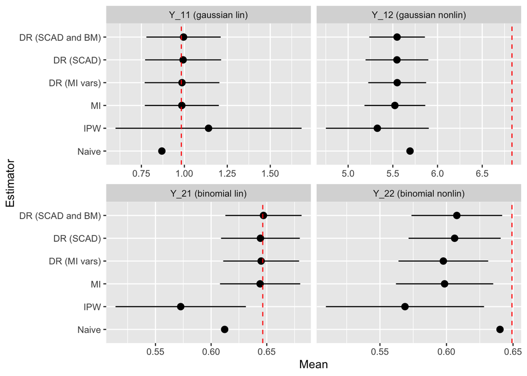

```r
ggplot(data = results, aes(x = estim, y = mean, ymin = lower_bound, ymax = upper_bound)) +
  geom_point() +
  geom_pointrange() +
  geom_hline(aes(yintercept = true), color = "red", linetype = "dashed") +
  facet_wrap(~y, scales = "free_x", labeller = labeller(y = c("Y_11" = "Y_11 (gaussian lin)",
                                                              "Y_12" = "Y_12 (gaussian nonlin)",
                                                              "Y_21" = "Y_21 (binomial lin)",
                                                              "Y_22" = "Y_22 (binomial nonlin)"))) +
  coord_flip() +
  labs(y = "Mean", x = "Estimator")
```